# Tibias

Joan Vilanova - David Sánchez

Junio 2022

# 1 Introducción

Queremos evaluar si hay un patrón de fractura tibial (AO) que se relacione más con las fracturas del maléolo posterior y si el patrón se relaciona con la energía del mecanismo de fractura (alta energía o no) y/o con la afectación de las partes blandas (fractura abierta o no).

# 2 Preprocesado y gestión de características

```r
if (!require('readxl')) install.packages('readxl')
library(readxl)
if (!require('dplyr')) install.packages('dplyr')
library(dplyr)
if (!require('ggplot2')) install.packages('ggplot2')
library(ggplot2)
if (!require('arules')) install.packages('arules')
library(arules)
if (!require("gridExtra")) install.packages("gridExtra")
library("gridExtra")
if (!require("ggmosaic")) install.packages("ggmosaic")
library(ggmosaic)
```

Cargo el archivo.

```r
path_tibias <- 'tibias.xlsx'

tibias <- suppressMessages(read_excel(path_tibias, col_names = TRUE)[,5:12])
names(tibias) <- c('Sexo', 'Edad', 'AO1', 'AO2', 'AO3', 'Fx_abierta', 'Alta_energía', 'Afectación_MP')
str(tibias)
```

```
## tibble [92 x 8] (S3: tbl_df/tbl/data.frame)
##  $ Sexo         : chr [1:92] "1" "1" "0" "1" ...
##  $ Edad         : num [1:92] 32 39 53 28 48 39 27 68 21 20 ...
##  $ AO1          : num [1:92] 42 42 42 42 42 42 42 42 42 42 ...
##  $ AO2          : chr [1:92] "C" "A" "A" "C" ...
##  $ AO3          : num [1:92] 3 1 1 2 1 1 1 2 2 2 ...
##  $ Fx_abierta   : chr [1:92] "No" "No" "Si - G.I (<1cm)" "No" ...
##  $ Alta_energía : chr [1:92] "0" "0" "0" "1" ...
##  $ Afectación_MP: chr [1:92] "0" "0" "1" "1" ...
```

Defino sus columnas: - Sexo: 0 mujer, 1 hombre. - Edad: edad en años. - AO1: 41 tibia proximal, 42 tibia diafisaria, 43 tibia distal. - AO2: A, B, C. Falta completar definición. - AO3: 1, 2, 3. Falta completar definición. - Fx_abierta: indica si hay o no afectación cutánea. - Alta_energía: traumatismo de alta energía; 0 no, 1 sí. - Afectación_MP: afectación del maléolo posterior; 0 no, 1 sí.

Resumen estadístico:

```r
summary(tibias)
```

```
##      Sexo                Edad            AO1         AO2
##  Length:92          Min.   :17.00   Min.   :41   Length:92
##  Class :character   1st Qu.:36.00   1st Qu.:42   Class :character
##  Mode  :character   Median :43.00   Median :42   Mode  :character
##                     Mean   :47.92   Mean   :42
##                     3rd Qu.:63.25   3rd Qu.:42
##                     Max.   :89.00   Max.   :43
##                     NA's   :8       NA's   :8
##       AO3         Fx_abierta        Alta_energía       Afectación_MP
##  Min.   :1.000   Length:92          Length:92          Length:92
##  1st Qu.:1.000   Class :character   Class :character   Class :character
##  Median :1.000   Mode  :character   Mode  :character   Mode  :character
##  Mean   :1.667
##  3rd Qu.:2.000
##  Max.   :3.000
##  NA's   :8
```

Busco valores nulos.

```r
print('Nulos (NA)')
```

```
## [1] "Nulos (NA)"
```

```r
colSums(is.na(tibias))
```

```
##          Sexo          Edad           AO1           AO2           AO3
##             6             8             8             8             8
##    Fx_abierta  Alta_energía Afectación_MP
##             8             5             6
```

Identifico valores NA.

```r
tibias[is.na(tibias$Edad),]
```

```
## # A tibble: 8 x 8
##   Sexo      Edad   AO1 AO2     AO3 Fx_abierta Alta_energía Afectación_MP
##   <chr>    <dbl> <dbl> <chr> <dbl> <chr>      <chr>        <chr>
## 1 <NA>        NA    NA <NA>     NA <NA>       <NA>         <NA>
## 2 1 HOMBRE    NA    NA <NA>     NA <NA>       0 no         0 no
## 3 0 MUJER     NA    NA <NA>     NA <NA>       1 si         1 si
## 4 <NA>        NA    NA <NA>     NA <NA>       <NA>         <NA>
## 5 <NA>        NA    NA <NA>     NA <NA>       28           25
## 6 <NA>        NA    NA <NA>     NA <NA>       <NA>         <NA>
## 7 <NA>        NA    NA <NA>     NA <NA>       <NA>         <NA>
## 8 <NA>        NA    NA <NA>     NA <NA>       <NA>         <NA>
```

```r
tibias <- tibias[!is.na(tibias$Edad),]
```

Busco valores nulos de nuevo.

```r
print('Nulos (NA)')
```

```
## [1] "Nulos (NA)"
```

```r
colSums(is.na(tibias))
```

```
##          Sexo          Edad           AO1           AO2           AO3
##             0             0             0             0             0
##    Fx_abierta  Alta_energía Afectación_MP
##             0             0             1
```

Elimino la fila con NA en campo Afectación_MP, ya que es la variable objetivo.

```r
tibias <- tibias[!is.na(tibias$Afectación_MP),]
```

Confirmo que no quedan valores nulos.

```r
print('Nulos (NA)')
```

```
## [1] "Nulos (NA)"
```

```r
colSums(is.na(tibias))
```

```
##          Sexo          Edad           AO1           AO2           AO3
##             0             0             0             0             0
##    Fx_abierta  Alta_energía Afectación_MP
##             0             0             0
```

Busco valores en blanco. No los hay.

```r
print('Valores en blanco')
```

```
## [1] "Valores en blanco"
```

```r
colSums(tibias == "")
```

```
##          Sexo          Edad           AO1           AO2           AO3
##             0             0             0             0             0
##    Fx_abierta  Alta_energía Afectación_MP
##             0             0             0
```

Renombro las clases por nombres más intuitivos.

```r
tibias[tibias$Sexo == 0, 'Sexo'] = 'Mujer'
tibias[tibias$Sexo == 1, 'Sexo'] = 'Hombre'

tibias[tibias$Alta_energía == 0, 'Alta_energía'] = 'No'
tibias[tibias$Alta_energía == 1, 'Alta_energía'] = 'Sí'

tibias[tibias$Afectación_MP == 0, 'Afectación_MP'] = 'No'
tibias[tibias$Afectación_MP == 1, 'Afectación_MP'] = 'Sí'

tibias[tibias$Fx_abierta == 'NO', 'Fx_abierta'] = 'No'
tibias[tibias$Fx_abierta == 'Si - G.I (<1cm)', 'Fx_abierta'] = 'Sí - G.I (<1cm)'
tibias[tibias$Fx_abierta == 'Si - G.II (1-10cm)', 'Fx_abierta'] = 'Sí - G.II (1-10cm)'
```

Creo una nueva columna, AO, con los campos AO1 - AO2 - AO3 unidos en un string.

```r
tibias <- tibias %>% mutate(AO = paste(as.character(AO1), AO2, as.character(AO3), sep=''))
```

Creo una nueva columna, Edad_f, con las franjas de edad.

```r
tibias <- tibias %>% mutate(Edad_f = discretize(tibias$Edad, method = 'fixed', breaks = c(10, 20, 30, 40, 50, 60, 70, 80, 90),
                                                labels = c('10-19 a',
                                                           '20-29 a',
                                                           '30-39 a',
                                                           '40-49 a',
                                                           '50-59 a',
                                                           '60-69 a',
                                                           '70-79 a',
                                                           '80-89 a')))
```

Transformo las variables categóricas en factores.

```r
tibias <- tibias %>% mutate(Sexo=as.factor(Sexo), Fx_abierta=as.factor(Fx_abierta),
                            AO1=as.factor(AO1), AO2=as.factor(AO2), AO3=as.factor(AO3),
                            Alta_energía=as.factor(Alta_energía), Afectación_MP=as.factor(Afectación_MP),
                            AO=as.factor(AO), Edad_f=as.factor(Edad_f))
str(tibias)
```

```
## tibble [83 x 10] (S3: tbl_df/tbl/data.frame)
##  $ Sexo         : Factor w/ 2 levels "Hombre","Mujer": 1 1 2 1 2 1 1 2 1 2 ...
##  $ Edad         : num [1:83] 32 39 53 28 48 39 27 68 20 57 ...
##  $ AO1          : Factor w/ 3 levels "41","42","43": 2 2 2 2 2 2 2 2 2 2 ...
##  $ AO2          : Factor w/ 3 levels "A","B","C": 3 1 1 3 1 1 1 2 2 1 ...
##  $ AO3          : Factor w/ 3 levels "1","2","3": 3 1 1 2 1 1 1 2 2 1 ...
##  $ Fx_abierta   : Factor w/ 3 levels "No","Sí - G.I (<1cm)",..: 1 1 2 1 1 1 1 1 1 2 ...
##  $ Alta_energía : Factor w/ 2 levels "No","Sí": 1 1 1 2 2 2 2 1 2 1 ...
##  $ Afectación_MP: Factor w/ 2 levels "No","Sí": 1 1 2 2 2 2 2 1 1 1 ...
##  $ AO           : Factor w/ 9 levels "41A1","42A1",..: 8 2 2 7 2 2 2 5 5 2 ...
##  $ Edad_f       : Factor w/ 8 levels "10-19 a","20-29 a",..: 3 3 5 2 4 3 2 6 2 5 ...
##   ..- attr(*, "discretized:breaks")= num [1:9] 10 20 30 40 50 60 70 80 90
##   ..- attr(*, "discretized:method")= chr "fixed"
```

Confirmo la correcta clasificación de la edad en franjas.

```r
tibias[,c('Edad', "Edad_f")]
```

```
## # A tibble: 83 x 2
##     Edad Edad_f
##    <dbl> <fct>
##  1    32 30-39 a
##  2    39 30-39 a
##  3    53 50-59 a
##  4    28 20-29 a
##  5    48 40-49 a
##  6    39 30-39 a
##  7    27 20-29 a
##  8    68 60-69 a
##  9    20 20-29 a
## 10    57 50-59 a
## # ... with 73 more rows
```

# 3 Análisis de los datos

Visualizo las diferentes variables según sexo.

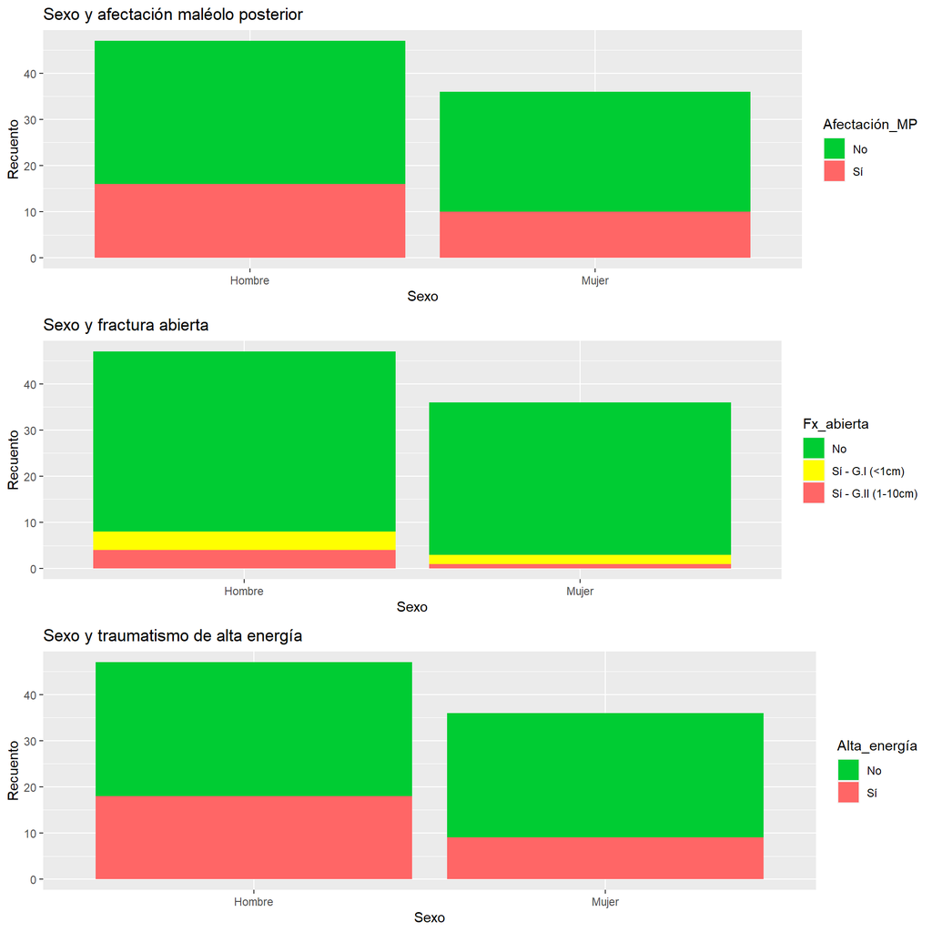

```r
g1 <- ggplot(data = tibias, aes(Sexo, fill = Afectación_MP)) +
  xlab('Sexo') +
  ylab('Recuento') +
  ggtitle('Sexo y afectación maléolo posterior') +
  scale_fill_manual(values=c("#00CC33", "#FF6666")) +
  geom_bar()

g2 <- ggplot(data = tibias, aes(Sexo, fill = Fx_abierta)) +
  xlab('Sexo') +
  ylab('Recuento') +
  ggtitle('Sexo y fractura abierta') +
  scale_fill_manual(values=c("#00CC33", "#FFFF00", "#FF6666")) +
  geom_bar()

g3 <- ggplot(data = tibias, aes(Sexo, fill = Alta_energía)) +
  xlab('Sexo') +
  ylab('Recuento') +
  ggtitle('Sexo y traumatismo de alta energía') +
  scale_fill_manual(values=c("#00CC33", "#FF6666")) +
  geom_bar()

grid.arrange(g1, g2, g3)
```

Visualizo las diferentes variables según edad.

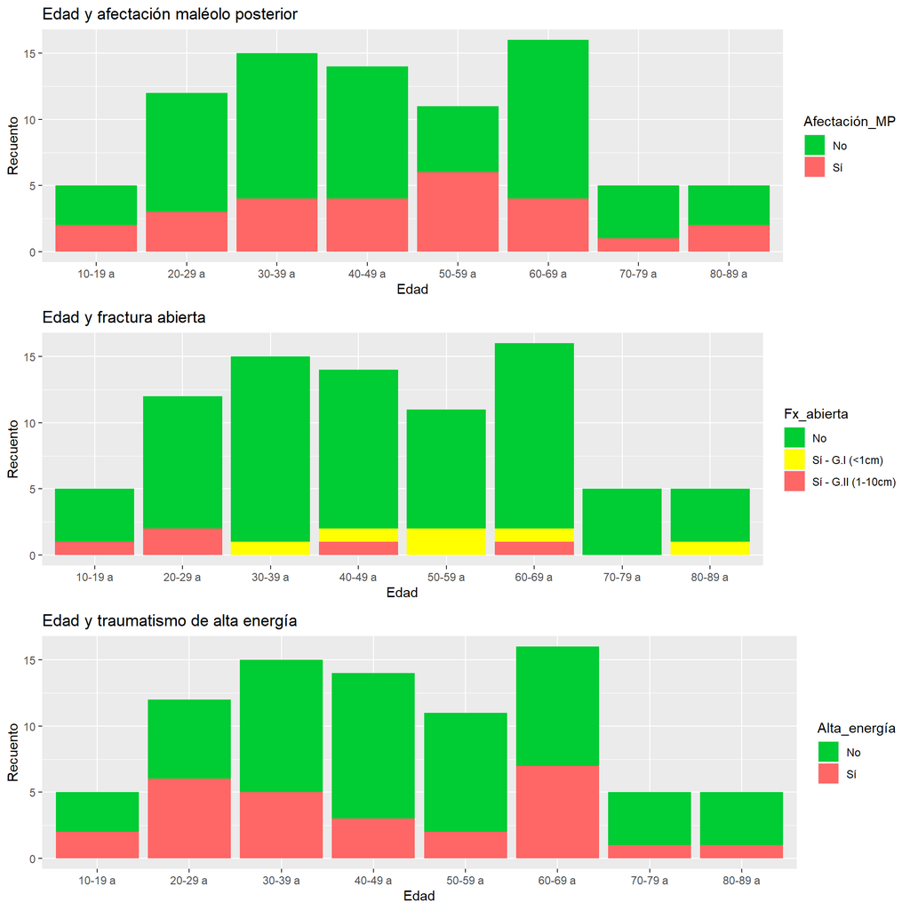

```r
g1 <- ggplot(data = tibias, aes(Edad_f, fill = Afectación_MP)) +
  xlab('Edad') +
  ylab('Recuento') +
  ggtitle('Edad y afectación maléolo posterior') +
  scale_fill_manual(values=c("#00CC33", "#FF6666")) +
  geom_bar()

g2 <- ggplot(data = tibias, aes(Edad_f, fill = Fx_abierta)) +
  xlab('Edad') +
  ylab('Recuento') +
  ggtitle('Edad y fractura abierta') +
  scale_fill_manual(values=c("#00CC33", "#FFFF00", "#FF6666")) +
  geom_bar()

g3 <- ggplot(data = tibias, aes(Edad_f, fill = Alta_energía)) +
  xlab('Edad') +
  ylab('Recuento') +
  ggtitle('Edad y traumatismo de alta energía') +
  scale_fill_manual(values=c("#00CC33", "#FF6666")) +
  geom_bar()

grid.arrange(g1, g2, g3)
```

Visualizo según patrón de fractura tibial.

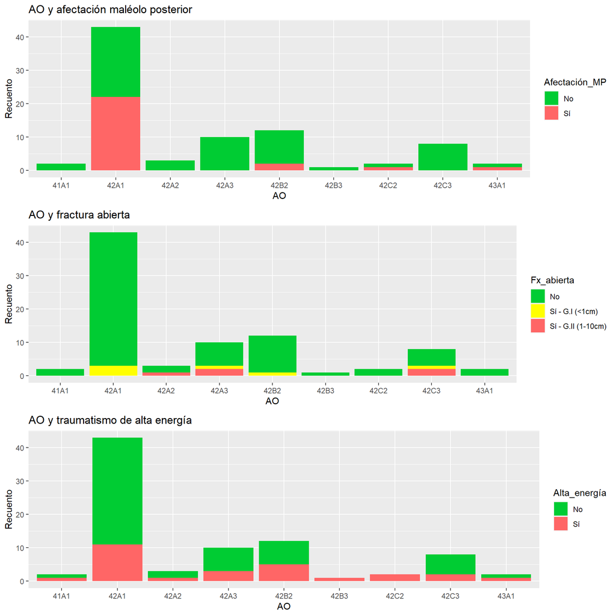

```r
g1 <- ggplot(data = tibias, aes(AO, fill = Afectación_MP)) +
  xlab('AO') +
  ylab('Recuento') +
  ggtitle('AO y afectación maléolo posterior') +
  scale_fill_manual(values=c("#00CC33", "#FF6666")) +
  geom_bar()

g2 <- ggplot(data = tibias, aes(AO, fill = Fx_abierta)) +
  xlab('AO') +
  ylab('Recuento') +
  ggtitle('AO y fractura abierta') +
  scale_fill_manual(values=c("#00CC33", "#FFFF00", "#FF6666")) +
  geom_bar()

g3 <- ggplot(data = tibias, aes(AO, fill = Alta_energía)) +
  xlab('AO') +
  ylab('Recuento') +
  ggtitle('AO y traumatismo de alta energía') +
  scale_fill_manual(values=c("#00CC33", "#FF6666")) +
  geom_bar()

grid.arrange(g1, g2, g3)
```

Visualizo las diferentes variables según AO1.

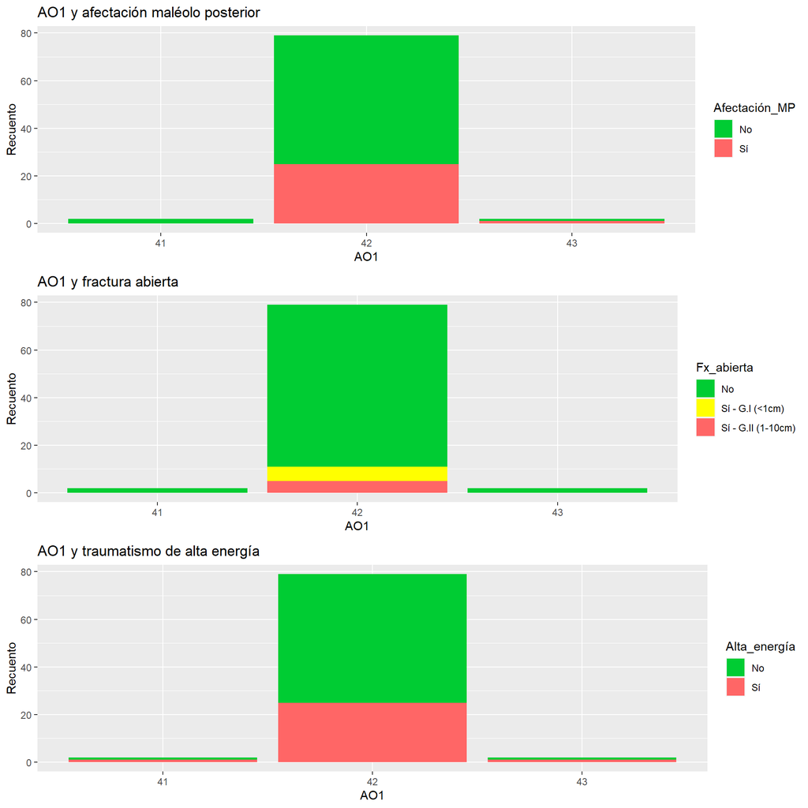

```r
g1 <- ggplot(data = tibias, aes(AO1, fill = Afectación_MP)) +
  xlab('AO1') +
  ylab('Recuento') +
  ggtitle('AO1 y afectación maléolo posterior') +
  scale_fill_manual(values=c("#00CC33", "#FF6666")) +
  geom_bar()

g2 <- ggplot(data = tibias, aes(AO1, fill = Fx_abierta)) +
  xlab('AO1') +
  ylab('Recuento') +
  ggtitle('AO1 y fractura abierta') +
  scale_fill_manual(values=c("#00CC33", "#FFFF00", "#FF6666")) +
  geom_bar()

g3 <- ggplot(data = tibias, aes(AO1, fill = Alta_energía)) +
  xlab('AO1') +
  ylab('Recuento') +
  ggtitle('AO1 y traumatismo de alta energía') +
  scale_fill_manual(values=c("#00CC33", "#FF6666")) +
  geom_bar()

grid.arrange(g1, g2, g3)
```

Visualizo las diferentes variables según AO2.

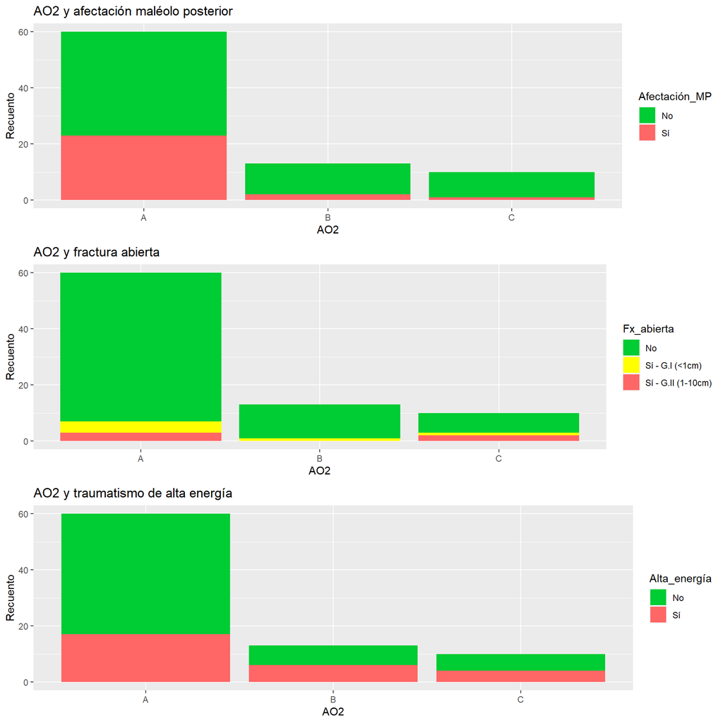

```r
g1 <- ggplot(data = tibias, aes(AO2, fill = Afectación_MP)) +
  xlab('AO2') +
  ylab('Recuento') +
  ggtitle('AO2 y afectación maléolo posterior') +
  scale_fill_manual(values=c("#00CC33", "#FF6666")) +
  geom_bar()

g2 <- ggplot(data = tibias, aes(AO2, fill = Fx_abierta)) +
  xlab('AO2') +
  ylab('Recuento') +
  ggtitle('AO2 y fractura abierta') +
  scale_fill_manual(values=c("#00CC33", "#FFFF00", "#FF6666")) +
  geom_bar()

g3 <- ggplot(data = tibias, aes(AO2, fill = Alta_energía)) +
  xlab('AO2') +
  ylab('Recuento') +
  ggtitle('AO2 y traumatismo de alta energía') +
  scale_fill_manual(values=c("#00CC33", "#FF6666")) +
  geom_bar()

grid.arrange(g1, g2, g3)
```

Visualizo las diferentes variables según AO3.

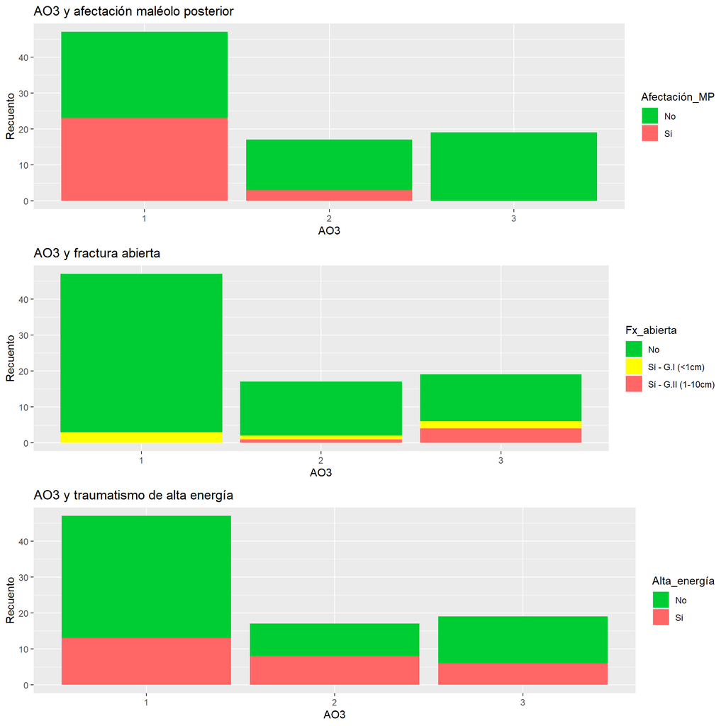

```r
g1 <- ggplot(data = tibias, aes(AO3, fill = Afectación_MP)) +
  xlab('AO3') +
  ylab('Recuento') +
  ggtitle('AO3 y afectación maléolo posterior') +
  scale_fill_manual(values=c("#00CC33", "#FF6666")) +
  geom_bar()

g2 <- ggplot(data = tibias, aes(AO3, fill = Fx_abierta)) +
  xlab('AO3') +
  ylab('Recuento') +
  ggtitle('AO3 y fractura abierta') +
  scale_fill_manual(values=c("#00CC33", "#FFFF00", "#FF6666")) +
  geom_bar()

g3 <- ggplot(data = tibias, aes(AO3, fill = Alta_energía)) +
  xlab('AO3') +
  ylab('Recuento') +
  ggtitle('AO3 y traumatismo de alta energía') +
  scale_fill_manual(values=c("#00CC33", "#FF6666")) +
  geom_bar()

grid.arrange(g1, g2, g3)
```

Examino si hay diferencias significativas entre los grupos de las variables categóricas con respecto a las variables numéricas (Edad) usando la función fun2 (definida a continuación).

```r
variables_categoricas <- c('Sexo', 'AO', 'AO1', 'AO2', 'AO3', 'Fx_abierta', 'Alta_energía', 'Afectación_MP')
variables_numericas <- c('Edad')


fun2 <- function(var_num, var_cat, df = tibias) {
  level_count <- c()
  for (i in unique(df[, var_cat])) {
    level_count <- append(level_count, i)
  }
  a <- length(level_count)  # la variable 'a' almacena cuántas clases hay en la categoría.
  if(a == 2) {
    b <- wilcox.test(get(var_num) ~ get(var_cat), data = df, exact = FALSE)
    print(noquote(paste('wilcox.test(', var_num, ' ~ ', var_cat, '): ', 'p.value ', b$p.value, sep = "")))
  }
  if(a > 2) {
    b <- kruskal.test(get(var_num) ~ get(var_cat), data = df)
    print(noquote(paste('kruskal.test(', var_num, ' ~ ', var_cat, '): ', 'p.value ', b$p.value, sep = "")))
  }
}


for (i in variables_numericas) {
  for (j in variables_categoricas) {
    fun2(i, j)
  }
}
```

```
## [1] wilcox.test(Edad ~ Sexo): p.value 0.0340733151559829
## [1] kruskal.test(Edad ~ AO): p.value 0.215456558263013
## [1] kruskal.test(Edad ~ AO1): p.value 0.716198356572834
## [1] kruskal.test(Edad ~ AO2): p.value 0.388709907489693
## [1] kruskal.test(Edad ~ AO3): p.value 0.0148132217410872
## [1] kruskal.test(Edad ~ Fx_abierta): p.value 0.213271175895774
## [1] wilcox.test(Edad ~ Alta_energía): p.value 0.373513201042546
## [1] wilcox.test(Edad ~ Afectación_MP): p.value 0.817424855976607
```

Para Edad sí que hay diferencias entre mujeres y hombres y entre las clases de AO3 (p < 0.05); en el resto de variables categóricas no hay diferencias de Edad entre sus clases.

Estudio la asociación entre variables categóricas.

Incluyo AO. Hay asociación entre AO y Afectación_MP.

```r
variables_categoricas <- c('Sexo', 'AO', 'Fx_abierta', 'Alta_energía', 'Afectación_MP', 'Edad_f')
comb_cat <- combn(variables_categoricas, 2)
for (i in 1:ncol(comb_cat)) {
  tab <- table(unlist(tibias[,comb_cat[,i][1]]), unlist(tibias[,comb_cat[,i][2]]))
  if(chisq.test(tab)$p.value <= 0.05){
    cat(paste(comb_cat[,i][1], ' ~ ', comb_cat[,i][2], ':', sep=''))
    print(chisq.test(tab))
    cat("\n\n")
  }
}
```

```
## AO ~ Afectación_MP:
##  Pearson's Chi-squared test
##
## data:  tab
## X-squared = 20.66, df = 8, p-value = 0.008107
```

Incluyo AO1. No devuelve resultados: AO1 no se asocia a otras variables categóricas.

```r
variables_categoricas <- c('Sexo', 'AO1', 'Fx_abierta', 'Alta_energía', 'Afectación_MP', 'Edad_f')
comb_cat <- combn(variables_categoricas, 2)
for (i in 1:ncol(comb_cat)) {
  tab <- table(unlist(tibias[,comb_cat[,i][1]]), unlist(tibias[,comb_cat[,i][2]]))
  if(chisq.test(tab)$p.value <= 0.05){
    cat(paste(comb_cat[,i][1], ' ~ ', comb_cat[,i][2], ':', sep=''))
    print(chisq.test(tab))
    cat("\n\n")
  }
}
```

Incluyo AO2. No devuelve resultados: AO2 no se asocia a otras variables categóricas.

```r
variables_categoricas <- c('Sexo', 'AO2', 'Fx_abierta', 'Alta_energía', 'Afectación_MP', 'Edad_f')
comb_cat <- combn(variables_categoricas, 2)
for (i in 1:ncol(comb_cat)) {
  tab <- table(unlist(tibias[,comb_cat[,i][1]]), unlist(tibias[,comb_cat[,i][2]]))
  if(chisq.test(tab)$p.value <= 0.05){
    cat(paste(comb_cat[,i][1], ' ~ ', comb_cat[,i][2], ':', sep=''))
    print(chisq.test(tab))
    cat("\n\n")
  }
}
```

Incluyo AO3. Hay asociación entre AO3 ~ Fx_abierta y AO3 ~ Afectación_MP.

```r
variables_categoricas <- c('Sexo', 'AO3', 'Fx_abierta', 'Alta_energía', 'Afectación_MP', 'Edad_f')
comb_cat <- combn(variables_categoricas, 2)
for (i in 1:ncol(comb_cat)) {
  tab <- table(unlist(tibias[,comb_cat[,i][1]]), unlist(tibias[,comb_cat[,i][2]]))
  if(chisq.test(tab)$p.value <= 0.05){
    cat(paste(comb_cat[,i][1], ' ~ ', comb_cat[,i][2], ':', sep=''))
    print(chisq.test(tab))
    cat("\n\n")
  }
}
```

```
## AO3 ~ Fx_abierta:
##  Pearson's Chi-squared test
##
## data:  tab
## X-squared = 11.326, df = 4, p-value = 0.02313
##
##
##
## AO3 ~ Afectación_MP:
##  Pearson's Chi-squared test
##
## data:  tab
## X-squared = 16.921, df = 2, p-value = 0.0002117
```

Para p ≤ 0.05, las variables tienen una asociación estadísticamente significativa (son dependientes, están asociadas), como ocurre entre: - AO ~ Afectación_MP (p-value = 0.008107). - AO3 ~ Fx_abierta (p-value = 0.02313). - AO3 ~ Afectación_MP (p-value = 0.0002117).

Lo muestro gráficamente.

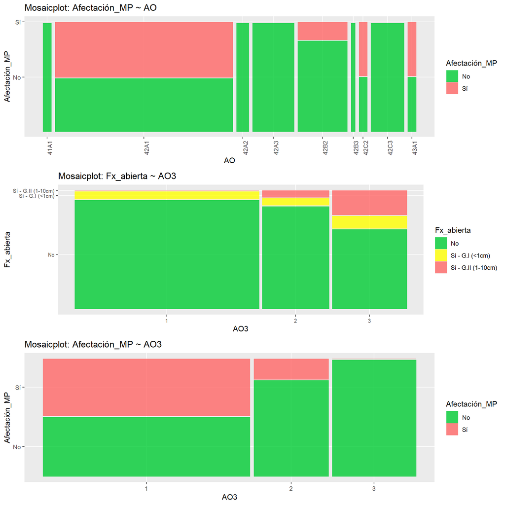

```r
g1 <- ggplot(data = tibias) +
  labs(title = 'Mosaicplot: Afectación_MP ~ AO') +
  theme(axis.text.x = element_text(angle = 90)) +
  scale_fill_manual(values=c("#00CC33", "#FF6666")) +
  geom_mosaic(aes(x=product(Afectación_MP, AO), fill = Afectación_MP))

g2 <- ggplot(data = tibias) +
  labs(title = 'Mosaicplot: Fx_abierta ~ AO3') +
  theme(axis.text=element_text(size=7.5)) +
  scale_fill_manual(values=c("#00CC33", "#FFFF00", "#FF6666")) +
  geom_mosaic(aes(x=product(Fx_abierta, AO3), fill = Fx_abierta))

g3 <- ggplot(data = tibias) +
  labs(title = 'Mosaicplot: Afectación_MP ~ AO3') +
  scale_fill_manual(values=c("#00CC33", "#FF6666")) +
  geom_mosaic(aes(x=product(Afectación_MP, AO3), fill = Afectación_MP))

grid.arrange(g1, g2, g3)
```

Y muestro sus tablas de contingencia.

```r
prop.table(table(tibias$Afectación_MP, tibias$AO), 2)
```

```
##
##           41A1      42A1      42A2      42A3      42B2      42B3      42C2
##   No 1.0000000 0.4883721 1.0000000 1.0000000 0.8333333 1.0000000 0.5000000
##   Sí 0.0000000 0.5116279 0.0000000 0.0000000 0.1666667 0.0000000 0.5000000
##
##           42C3      43A1
##   No 1.0000000 0.5000000
##   Sí 0.0000000 0.5000000
```

Para los patrones 42A1, 42B2, 42C2 y 43A1, hay afectación del maléolo posterior en un 51%, 17%, 50% y 50%, respectivamente. Para los patrones 41A1, 42A2, 42A3, 42B3 y 42C3 no hay afectación del maléolo posterior.

```r
prop.table(table(tibias$Fx_abierta, tibias$AO3), 2)
```

```
##
##                               1          2          3
##   No                 0.93617021 0.88235294 0.68421053
##   Sí - G.I (<1cm)    0.06382979 0.05882353 0.10526316
##   Sí - G.II (1-10cm) 0.00000000 0.05882353 0.21052632
```

Para AO3 de tipo 1, un 6% tiene fx abierta grado I. Para AO3 de tipo 2, un 6% tiene fx abierta grado I y un 6% tiene fx abierta grado II. Para AO3 de tipo 3, un 11% tiene fx abierta grado I y un 21% tiene fx abierta grado II.

```r
prop.table(table(tibias$Afectación_MP, tibias$AO3), 2)
```

```
##
##              1         2         3
##   No 0.5106383 0.8235294 1.0000000
##   Sí 0.4893617 0.1764706 0.0000000
```

Para AO3 de tipo 1, un 49% tiene afectación de maléolo posterior. Para AO3 de tipo 2, un 18% tiene afectación de maléolo posterior. Para AO3 de tipo 3 no se observa afectación del maléolo posterior.

Entre el resto de variables categóricas no encontramos asociación significativa.

# 4 Conclusiones

En los datos tratados:

- Para los patrones 42A1, 42C2 y 43A1, hay afectación del maléolo posterior en un 51%, 50% y 50%, respectivamente.
- Para AO3 de tipo 3, un 11% tiene fx abierta grado I y un 21% tiene fx abierta grado II.
- Para AO3 de tipo 1, un 49% tiene afectación de maléolo posterior.

Hay asociación estadísticamente significativa entre patrón AO ~ Afectación_MP, AO3 ~ Fx_abierta y AO3 ~ Afectación_MP. Concretamente:

- Dentro de la variable AO, las clases 42A1, 42B2, 42C2 y 43A1 tienen más afectación del maléolo posterior que el resto.
- Dentro de la variable AO3, los tipo 2 y 3 se relacionan más con fractura abierta (grados I y II), siendo superior la incidencia de fractura abierta y su gravedad en el tipo 3.
- Dentro de la variable AO3, las clases 1 y 2 tienen más afectación de maléolo posterior, siendo mayor la incidencia de afectación de maléolo posterior en la clase 1.

# 5 Bibliografía

- https://github.com/tidyverse/readxl/issues/580
- https://www.rdocumentation.org/packages/readxl/versions/0.1.1/topics/read_excel
- https://ggplot2.tidyverse.org/reference/geom_bar.html
- https://www.rdocumentation.org/packages/arules/versions/1.7-3/topics/discretize
- http://www.sthda.com/english/wiki/ggplot2-colors-how-to-change-colors-automatically-and-manually
- https://stackoverflow.com/questions/18679660/r-chisq-test-with-p-values-na
- https://www.rdocumentation.org/packages/base/versions/3.6.2/topics/table
- https://discuss.analyticsvidhya.com/t/how-to-get-the-proportion-in-table-command-of-r/6741
- https://www.rdocumentation.org/packages/base/versions/3.6.2/topics/prop.table
- https://sphweb.bumc.bu.edu/otlt/MPH-Modules/PH717-QuantCore/PH717-Module6-RandomError/PH717-Module6-RandomError12.html